# Project: Investigate a Dataset (No-Show Appointments)

- Introduction
- Data Wrangling
- Exploratory Data Analysis
- Conclusions

## Introduction

> This dataset from Brazil is recorded for a 100k medical appointments. Among these appointments, a few ended in no-show of the patients. We investigate this dataset to predict if an appointment would result in a no-show.

> First, the dataset is investigated to understand different features and to perform any neccessary cleaning. The distribution of several features is examined to better understand the data. The corrolation between no-show and different features is then investiageted. A final investiagation focuses on the gender and age features and their corrolation to no-show events.

### Import neccessary libraries

```python
import pandas as pd
import numpy as np
import matplotlib.pyplot as plt
%matplotlib inline
```

## Data Wrangling

> The dataset is explored and tested for cleanliness (i.e. missing values, outliers, duplicates).

### 1) General Properties

```python
# Load your data and print out a few lines. Perform operations to inspect data
#   types and look for instances of missing or possibly errant data.
df = pd.read_csv('noshowappointment.csv')
df.head()
```

|  | PatientId | AppointmentID | Gender | ScheduledDay | AppointmentDay | Age | Neighbourhood | Scholarship | Hipertension | Diabetes | Alcoholism | Handcap | SMS_received | No-show |
| --- | --- | --- | --- | --- | --- | --- | --- | --- | --- | --- | --- | --- | --- | --- |
| 0 | 2.987250e+13 | 5642903 | F | 2016-04-29T18:38:08Z | 2016-04-29T00:00:00Z | 62 | JARDIM DA PENHA | 0 | 1 | 0 | 0 | 0 | 0 | No |
| 1 | 5.589978e+14 | 5642503 | M | 2016-04-29T16:08:27Z | 2016-04-29T00:00:00Z | 56 | JARDIM DA PENHA | 0 | 0 | 0 | 0 | 0 | 0 | No |
| 2 | 4.262962e+12 | 5642549 | F | 2016-04-29T16:19:04Z | 2016-04-29T00:00:00Z | 62 | MATA DA PRAIA | 0 | 0 | 0 | 0 | 0 | 0 | No |
| 3 | 8.679512e+11 | 5642828 | F | 2016-04-29T17:29:31Z | 2016-04-29T00:00:00Z | 8 | PONTAL DE CAMBURI | 0 | 0 | 0 | 0 | 0 | 0 | No |
| 4 | 8.841186e+12 | 5642494 | F | 2016-04-29T16:07:23Z | 2016-04-29T00:00:00Z | 56 | JARDIM DA PENHA | 0 | 1 | 1 | 0 | 0 | 0 | No |

### 2) Check for null values and different data types

```python
df.info()
```

```
<class 'pandas.core.frame.DataFrame'>
RangeIndex: 110527 entries, 0 to 110526
Data columns (total 14 columns):
PatientId         110527 non-null float64
AppointmentID     110527 non-null int64
Gender            110527 non-null object
ScheduledDay      110527 non-null object
AppointmentDay    110527 non-null object
Age               110527 non-null int64
Neighbourhood     110527 non-null object
Scholarship       110527 non-null int64
Hipertension      110527 non-null int64
Diabetes          110527 non-null int64
Alcoholism        110527 non-null int64
Handcap           110527 non-null int64
SMS_received      110527 non-null int64
No-show           110527 non-null object
dtypes: float64(1), int64(8), object(5)
memory usage: 11.8+ MB
```

**>> For all of the features of the dataset, no null values were found.**

### 3) Check for any duplicates

```python
sum(df.duplicated())
```

```
0
```

**>> There are no duplicates.**

### 4) Explore the distribution of different numerical features

```python
df.describe()
```

|  | PatientId | AppointmentID | Age | Scholarship | Hipertension | Diabetes | Alcoholism | Handcap | SMS_received |
| --- | --- | --- | --- | --- | --- | --- | --- | --- | --- |
| count | 1.105270e+05 | 1.105270e+05 | 110527.000000 | 110527.000000 | 110527.000000 | 110527.000000 | 110527.000000 | 110527.000000 | 110527.000000 |
| mean | 1.474963e+14 | 5.675305e+06 | 37.088874 | 0.098266 | 0.197246 | 0.071865 | 0.030400 | 0.022248 | 0.321026 |
| std | 2.560949e+14 | 7.129575e+04 | 23.110205 | 0.297675 | 0.397921 | 0.258265 | 0.171686 | 0.161543 | 0.466873 |
| min | 3.921784e+04 | 5.030230e+06 | -1.000000 | 0.000000 | 0.000000 | 0.000000 | 0.000000 | 0.000000 | 0.000000 |
| 25% | 4.172614e+12 | 5.640286e+06 | 18.000000 | 0.000000 | 0.000000 | 0.000000 | 0.000000 | 0.000000 | 0.000000 |
| 50% | 3.173184e+13 | 5.680573e+06 | 37.000000 | 0.000000 | 0.000000 | 0.000000 | 0.000000 | 0.000000 | 0.000000 |
| 75% | 9.439172e+13 | 5.725524e+06 | 55.000000 | 0.000000 | 0.000000 | 0.000000 | 0.000000 | 0.000000 | 1.000000 |
| max | 9.999816e+14 | 5.790484e+06 | 115.000000 | 1.000000 | 1.000000 | 1.000000 | 1.000000 | 4.000000 | 1.000000 |

**>> Age: the mean and median age is 37 with a minimum of -1 (can't be interpretted) and a maximum of 115**

**>> Scholarship: about 9.8% of patients receive the scholarship**

**>> Hipertension: about 19.7% suffer from Hipertension**

**>> Diabetes: 7.2% have diabetes**

**>> Alcoholism: 3% are alcohol-addicts**

**>> Handcap: Less than 2% have one or more handcap**

**>> SMS_receieved: 32% sent (or received) SMSs before appointment**

### 5) Explore how many unique values for each feature.

```python
df.nunique()
```

```
PatientId          62299
AppointmentID     110527
Gender                 2
ScheduledDay      103549
AppointmentDay        27
Age                  104
Neighbourhood         81
Scholarship            2
Hipertension           2
Diabetes               2
Alcoholism             2
Handcap                5
SMS_received           2
No-show                2
dtype: int64
```

**>> The data was collected across 27 days for 81 areas and 62299 patients.**

### 6) Remove unneccessary columns.

```python
df.drop(columns=['AppointmentID','ScheduledDay'],inplace=True)
```

**>> The removed columns doesn't contribute to future exploration, thus they were removed.**

## Exploratory Data Analysis

**The Analysis is done in two ways:**

```
1) Examine features individuallly (1d)
2) Examine relations between different features and No-show feature. (2d)
```

**Histogram, Bar, and line plots were used for illustrations.**

## 1) Eaxmine features individually

### a) No-show

```python
#Create a no-show and show masks for later use
No_Show = df['No-show'] == 'Yes'
total_no_show = sum(No_Show)
Show = df['No-show'] == 'No'
total_show = sum(Show)
print("No-show Ratio: ", total_no_show/(total_no_show+total_show))
```

```
No-show Ratio:  0.20193255946510807
```

**>> About 20% of appointments ended up with no-show**

```
No     88208
Yes    22319
Name: No-show, dtype: int64
```

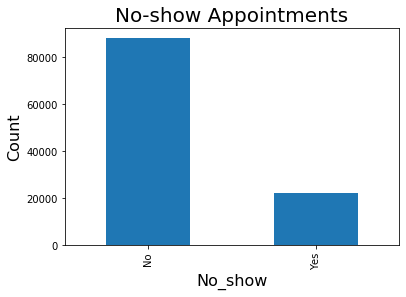

```python
df_no_show = df['No-show'].value_counts()
df_no_show.plot(kind='bar');
plt.title('No-show Appointments',fontsize=20);
plt.xlabel('No_show',fontsize=16);
plt.ylabel('Count',fontsize=16);
print(df_no_show)
```

**>> 22319 patients didn't show for the appointment while 88208 did**

### b) Age

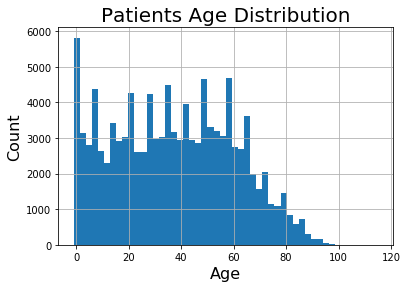

```python
df.Age.hist(bins=50);
plt.title('Patients Age Distribution',fontsize=20);
plt.xlabel('Age',fontsize=16);
plt.ylabel('Count',fontsize=16);
```

**>> The age of infancy (0~5) has the highest number of patients while the number of patients diminishes quickly after 70**

### c) Gender

```
F    71840
M    38687
Name: Gender, dtype: int64
```

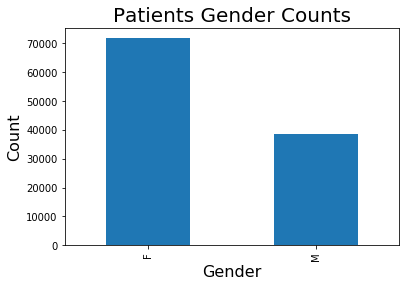

```python
df_gender = df.Gender.value_counts()
print(df_gender)
df_gender.plot(kind='bar');
plt.title('Patients Gender Counts',fontsize=20);
plt.xlabel('Gender',fontsize=16);
plt.ylabel('Count',fontsize=16);
```

### d) Neighbourhood

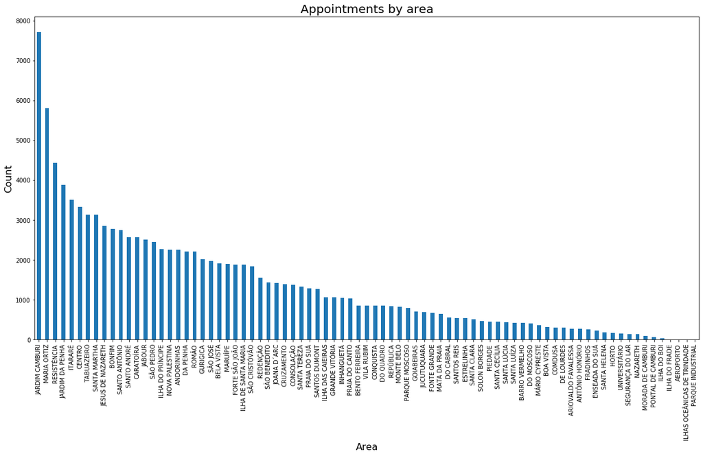

```python
df.Neighbourhood.value_counts().plot(kind='bar',figsize=(20,10));
plt.title('Appointments by area',fontsize=20);
plt.xlabel('Area',fontsize=16);
plt.ylabel('Count',fontsize=16);
```

**>> Some neighbourhoods are receiving far more patients than others. This might be due to economic status of the area and health services within it.**

### e) Appointment Day

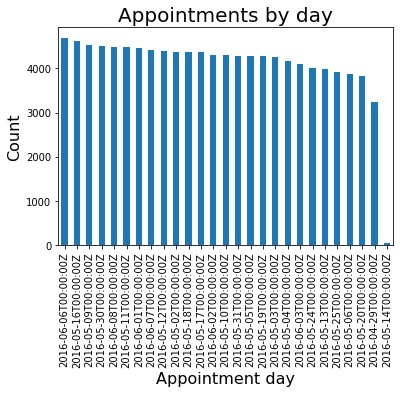

```python
df.AppointmentDay.value_counts().plot(kind='bar')
plt.title('Appointments by day',fontsize=20);
plt.xlabel('Appointment day',fontsize=16);
plt.ylabel('Count',fontsize=16);
```

**>> Most days have received a reasonable number of patients except for May 14th (Can't think of something special about this day except that it was a Saturday which applies to other days in the dataset).**

## 2) Eaxmine features in 2D

**>> The ratio between no-show patients and total number of patients is inspected for different features as follows:**

### a) Age => No-show

```
115    0.600000
14     0.282648
13     0.274705
15     0.265896
9      0.265306
25     0.264264
17     0.262425
24     0.258454
22     0.255087
19     0.255016
Name: Age, dtype: float64
```

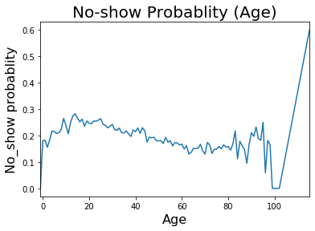

```python
No_show_age = df[No_Show].Age.value_counts()
Total_by_Age = df.Age.value_counts()
No_show_ratio = No_show_age/Total_by_Age
No_show_ratio.fillna(0,inplace=True)
No_show_ratio.plot()
plt.title('No-show Probablity (Age)',fontsize=20);
plt.xlabel('Age',fontsize=16);
plt.ylabel('No_show probablity',fontsize=16);
No_show_ratio.sort_values(ascending=False).head(10)
```

**>> The no-show proablity is mostly around 20% for different ages. The maximum of 60% at the age of 115 can be considered and outlier due to the low number of patients. However, we can notice significant rise around the age of 20 (maybe, youth are too busy to show for their appointments).**

### b) SMS recieving => No-show

```
SMS_received:
 0    0.167033
1    0.275745
Name: SMS_received, dtype: float64
```

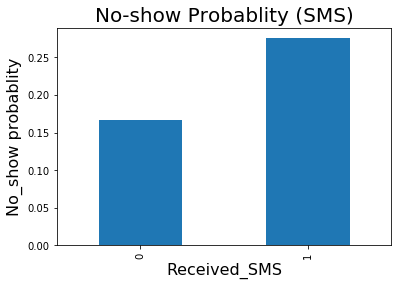

```python
No_show_SMS = df[No_Show].SMS_received.value_counts()
Total_by_SMS = df.SMS_received.value_counts()
No_show_ratio = No_show_SMS/Total_by_SMS
print("SMS_received: \n",No_show_ratio)
No_show_ratio.fillna(0,inplace=True)
No_show_ratio.plot(kind='bar')
plt.title('No-show Probablity (SMS)',fontsize=20);
plt.xlabel('Received_SMS',fontsize=16);
plt.ylabel('No_show probablity',fontsize=16);
```

**>> Receiving a message seems to have a good corrolation with no-show for appointments. Eventhough, receiving a message should work as a reminder to reduce the probability of no-show.**

### c) PatientId => No-show

```
Always not showing:  8145
Always showing:  44636
```

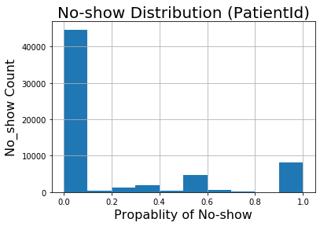

```python
No_show_patient = df[No_Show].PatientId.value_counts()
Total_by_patient = df.PatientId.value_counts()
No_show_ratio = No_show_patient/Total_by_patient
No_show_ratio.fillna(0,inplace=True)
No_show_ratio.hist()
plt.title('No-show Distribution (PatientId)',fontsize=20);
plt.xlabel('Propablity of No-show',fontsize=16);
plt.ylabel('No_show Count',fontsize=16);
print("Always not showing: ",sum(No_show_ratio == 1))
print("Always showing: ",sum(No_show_ratio == 0))
```

**>> By considering the patient ID, it can be shown that certain patients never show-up for appointments (8145) while others always show (44636) which is more than two thirds of the recorded patients. A careful study of these two extreme cases can result in better understanding of the dataset**

### d) Neighbourhood => No-show

```
ILHAS OCEÂNICAS DE TRINDADE    1.000000
SANTOS DUMONT                  0.289185
SANTA CECÍLIA                  0.274554
SANTA CLARA                    0.264822
ITARARÉ                        0.262664
                                 ...
SOLON BORGES                   0.147122
MÁRIO CYPRESTE                 0.145553
AEROPORTO                      0.125000
ILHA DO BOI                    0.085714
PARQUE INDUSTRIAL              0.000000
Name: Neighbourhood, Length: 81, dtype: float64
```

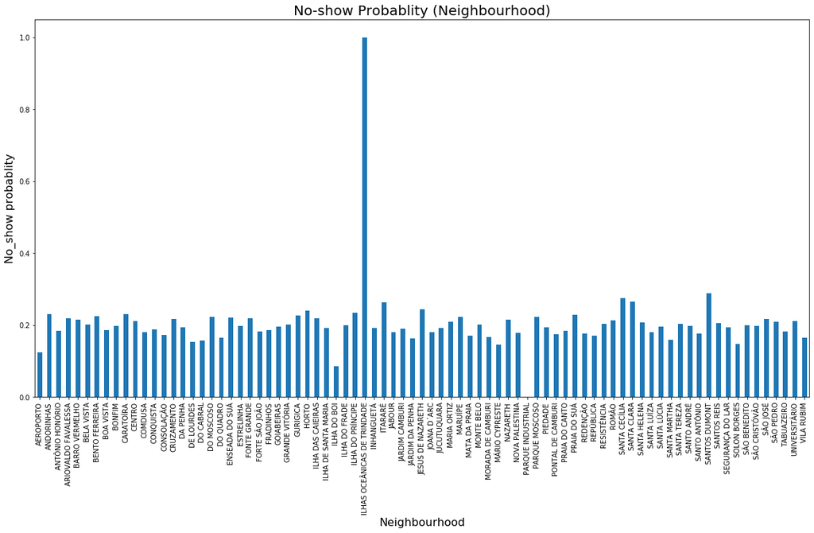

```python
No_show_Neighbourhood = df[No_Show].Neighbourhood.value_counts()
Total_by_Neighbourhood = df.Neighbourhood.value_counts()
No_show_ratio = No_show_Neighbourhood/Total_by_Neighbourhood
No_show_ratio.fillna(0,inplace=True)
No_show_ratio.plot(kind='bar',figsize=(20,10))
plt.title('No-show Probablity (Neighbourhood)',fontsize=20);
plt.xlabel('Neighbourhood',fontsize=16);
plt.ylabel('No_show probablity',fontsize=16);
print(No_show_ratio.sort_values(ascending=False))
```

**>> The no-show cases aren't highly dependent on the neighbourhood. Most neighbourhoods have no-show probablities of about 20%. Extreme cases of 100% and 0% do exist due to low number of patients in these neighbourhoods.**

### e) AppointmentDay => No-show

```
count    27.000000
mean      0.203189
std       0.018402
min       0.172806
25%       0.189674
50%       0.196822
75%       0.219652
max       0.234848
Name: AppointmentDay, dtype: float64
```

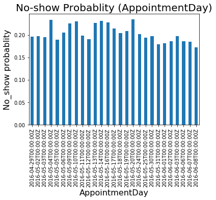

```python
No_show_AppointmentDay = df[No_Show].AppointmentDay.value_counts()
Total_by_AppointmentDay = df.AppointmentDay.value_counts()
No_show_ratio = No_show_AppointmentDay/Total_by_AppointmentDay
No_show_ratio.fillna(0,inplace=True)
No_show_ratio.plot(kind='bar')
plt.title('No-show Probablity (AppointmentDay)',fontsize=20);
plt.xlabel('AppointmentDay',fontsize=16);
plt.ylabel('No_show probablity',fontsize=16);
print(No_show_ratio.sort_values(ascending=False).describe())
```

**>> The dependance of the no-show cases on the appointment day is very low. All days have a no-show probablity of about 20%.**

### f) Scholarship => No-show

```
No-show Probablity (Scholarship)
 0    0.198072
1    0.237363
Name: Scholarship, dtype: float64
```

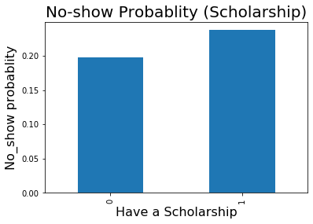

```python
No_show_Scholarship = df[No_Show].Scholarship.value_counts()
Total_by_Scholarship = df.Scholarship.value_counts()
No_show_ratio = No_show_Scholarship/Total_by_Scholarship
No_show_ratio.fillna(0,inplace=True)
print("No-show Probablity (Scholarship) \n",No_show_ratio)
No_show_ratio.plot(kind='bar')
plt.title('No-show Probablity (Scholarship)',fontsize=20);
plt.xlabel('Have a Scholarship',fontsize=16);
plt.ylabel('No_show probablity',fontsize=16);
```

**>> Those with a scholarship tends to have a higher no-show probablity (24%) than those with no scholarship (20%). This might be due to having a sponsor paying for the appointment (No big loss).**

### g) Alcoholism => No-show

```
No-show Probablity (Alcoholism)
 0    0.201946
1    0.201488
Name: Alcoholism, dtype: float64
```

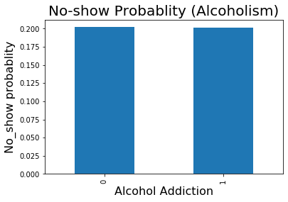

```python
No_show_Alcoholism = df[No_Show].Alcoholism.value_counts()
Total_by_Alcoholism = df.Alcoholism.value_counts()
No_show_ratio = No_show_Alcoholism/Total_by_Alcoholism
No_show_ratio.fillna(0,inplace=True)
print("No-show Probablity (Alcoholism) \n",No_show_ratio)
No_show_ratio.plot(kind='bar')
plt.title('No-show Probablity (Alcoholism)',fontsize=20);
plt.xlabel('Alcohol Addiction',fontsize=16);
plt.ylabel('No_show probablity',fontsize=16);
```

**>> Alcoholism doesn't significantly affect the no-show probablity (independent of alcoholism, probablity remains at about 20%).**

### h) Gender => No-show

```
No-show Probablity (Gender)
 F    0.203146
M    0.199679
Name: Gender, dtype: float64
```

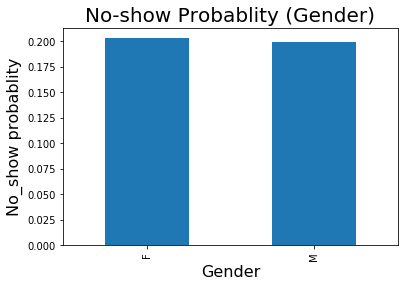

```python
No_show_Gender = df[No_Show].Gender.value_counts()
Total_by_Gender = df.Gender.value_counts()
No_show_ratio = No_show_Gender/Total_by_Gender
No_show_ratio.fillna(0,inplace=True)
print("No-show Probablity (Gender) \n",No_show_ratio)
No_show_ratio.plot(kind='bar')
plt.title('No-show Probablity (Gender)',fontsize=20);
plt.xlabel('Gender',fontsize=16);
plt.ylabel('No_show probablity',fontsize=16);
```

**>> The no-show probablity is independent of gender. Both males and females has a no-show probablity of about 20%.**

### i) Handcap => No-show

```
No-show Probablity (Handcap)
 0    0.202353
1    0.179236
2    0.202186
3    0.230769
4    0.333333
Name: Handcap, dtype: float64
```

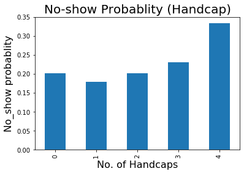

```python
No_show_Handcap = df[No_Show].Handcap.value_counts()
Total_by_Handcap = df.Handcap.value_counts()
No_show_ratio = No_show_Handcap/Total_by_Handcap
No_show_ratio.fillna(0,inplace=True)
print("No-show Probablity (Handcap) \n",No_show_ratio)
No_show_ratio.plot(kind='bar')
plt.title('No-show Probablity (Handcap)',fontsize=20);
plt.xlabel('No. of Handcaps',fontsize=16);
plt.ylabel('No_show probablity',fontsize=16);
```

**>> Ignoring cases of 0 handcap, we can see a trend showing an increase in the no-show probablity with the increase of number of handcaps.**

### j) Hipertension => No-show

```
No-show Probablity (Hipertension)
 0    0.209037
1    0.173020
Name: Hipertension, dtype: float64
```

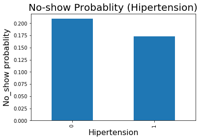

```python
No_show_Hipertension = df[No_Show].Hipertension.value_counts()
Total_by_Hipertension = df.Hipertension.value_counts()
No_show_ratio = No_show_Hipertension/Total_by_Hipertension
No_show_ratio.fillna(0,inplace=True)
print("No-show Probablity (Hipertension) \n",No_show_ratio)
No_show_ratio.plot(kind='bar')
plt.title('No-show Probablity (Hipertension)',fontsize=20);
plt.xlabel('Hipertension',fontsize=16);
plt.ylabel('No_show probablity',fontsize=16);
```

**>> Patients with hipertension have a lower no-show probablity. Maybe, because they worry more about the risk of high blood pressure.**

### k) Diabetes => No-show

```
No-show Probablity (Diabetes)
 0    0.203628
1    0.180033
Name: Diabetes, dtype: float64
```

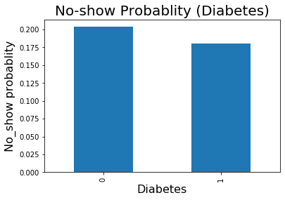

```python
No_show_Diabetes = df[No_Show].Diabetes.value_counts()
Total_by_Diabetes = df.Diabetes.value_counts()
No_show_ratio = No_show_Diabetes/Total_by_Diabetes
No_show_ratio.fillna(0,inplace=True)
print("No-show Probablity (Diabetes) \n",No_show_ratio)
No_show_ratio.plot(kind='bar')
plt.title('No-show Probablity (Diabetes)',fontsize=20);
plt.xlabel('Diabetes',fontsize=16);
plt.ylabel('No_show probablity',fontsize=16);
```

**>> Patients with diabetes have a lower no-show probablity. Maybe, they worry about high blood sugar.**

## Conclusions

**It was an interesting dataset to work with. It seems a lot of patients doesn't show up to their appointments (20% of them). Among the patients, females seem to worry more about the health than males do. The appointements made on a certain day in a cetain area aren't consistent. This would suggest some improper data collection or the unfairness of the distribution of the service centers.**

**By examining the relation between different features and the no-show probablity, the following features were found to have some significance on the no-show probablity:**

- Age: Youth are more inclined not to show up for the appointments.
- Received_SMS: Receiving an SMS increased the no-show probablity.
- Patient_Id: Some patients tend to always show for appointment while others never do.
- Scholarship: Patients with scholarship are more likely not to show for the appointment.
- Handcap: Patients with handcap has a higher no-show probablity.
- Hipertension: Patients with hipertension are more likely to show up for appointment.
- Diabetes: Patients with diabetes are more likely to show up for appointment.

**Other features didn't significantly affect the no-show probablity.**